# AutoData_CaseStudy

```python
#Mitsubishi
x=mergerdata.replace({'Owner':{'Mitsubishi':'Volkswagen'}})
x['Price'][x['Owner']=='Volkswagen'] = x['Price'][x['Owner']=='Volkswagen']+(x['Price'][x['Owner']=='Volkswagen']*0.05)
x['Revenue']=x['Price']*x['Quantity']
n=np.sum(x['Revenue'])
x['s_jt']=x['Revenue']/n
x=x.groupby(['Owner']).aggregate({'s_jt':'sum'})
x.reset_index(level=0, inplace=True)
x=x.rename(columns={'Owner':'Owner','s_jt':'s_t^f'})
x['HHI']=(x['s_t^f']*100)**2
np.sum(x['HHI'])
#2015 HHI 1142.44
#After merger HHI is 1217.33. Change in HHI is 74.89 ----> Will not be investigated
```

```
1217.333584005472
```

```python
#Ssangyong
x=mergerdata.replace({'Owner':{'Ssangyong':'Volkswagen'}})
x['Price'][x['Owner']=='Volkswagen'] = x['Price'][x['Owner']=='Volkswagen']+(x['Price'][x['Owner']=='Volkswagen']*0.05)
x['Revenue']=x['Price']*x['Quantity']
n=np.sum(x['Revenue'])
x['s_jt']=x['Revenue']/n
x=x.groupby(['Owner']).aggregate({'s_jt':'sum'})
x.reset_index(level=0, inplace=True)
x=x.rename(columns={'Owner':'Owner','s_jt':'s_t^f'})
x['HHI']=(x['s_t^f']*100)**2
np.sum(x['HHI'])
#2015 HHI 1142.44
#After merge HHI 1187.63. Change in HHI is 45.19 ----> Will not be investigated
```

```
1187.6258235488413
```

```python
#Subaru
x=mergerdata.replace({'Owner':{'Subaru':'Volkswagen'}})
x['Price'][x['Owner']=='Volkswagen'] = x['Price'][x['Owner']=='Volkswagen']+(x['Price'][x['Owner']=='Volkswagen']*0.05)
x['Revenue']=x['Price']*x['Quantity']
n=np.sum(x['Revenue'])
x['s_jt']=x['Revenue']/n
x=x.groupby(['Owner']).aggregate({'s_jt':'sum'})
x.reset_index(level=0, inplace=True)
x=x.rename(columns={'Owner':'Owner','s_jt':'s_t^f'})
x['HHI']=(x['s_t^f']*100)**2
np.sum(x['HHI'])
#2015 HHI 1142.44
#After merger HHI 1182.35. Change in HHI is 39.91 ----> Will not be investigated
```

```
1182.3505649693839
```

```python
#Suzuki
x=mergerdata.replace({'Owner':{'Suzuki':'Volkswagen'}})
x['Price'][x['Owner']=='Volkswagen'] = x['Price'][x['Owner']=='Volkswagen']+(x['Price'][x['Owner']=='Volkswagen']*0.05)
x['Revenue']=x['Price']*x['Quantity']
n=np.sum(x['Revenue'])
x['s_jt']=x['Revenue']/n
x=x.groupby(['Owner']).aggregate({'s_jt':'sum'})
x.reset_index(level=0, inplace=True)
x=x.rename(columns={'Owner':'Owner','s_jt':'s_t^f'})
x['HHI']=(x['s_t^f']*100)**2
np.sum(x['HHI'])
#2015 HHI 1142.44
#After merger HHI 1183.42. Change in HHI is 40.98 ----> Will not be investigated
```

```
1183.4151003404045
```

```python
#Saab
x=mergerdata.replace({'Owner':{'Saab':'Volkswagen'}})
x['Price'][x['Owner']=='Volkswagen'] = x['Price'][x['Owner']=='Volkswagen']+(x['Price'][x['Owner']=='Volkswagen']*0.05)
x['Revenue']=x['Price']*x['Quantity']
n=np.sum(x['Revenue'])
x['s_jt']=x['Revenue']/n
x=x.groupby(['Owner']).aggregate({'s_jt':'sum'})
x.reset_index(level=0, inplace=True)
x=x.rename(columns={'Owner':'Owner','s_jt':'s_t^f'})
x['HHI']=(x['s_t^f']*100)**2
np.sum(x['HHI'])
#2015 HHI 1142.44
#After merger HHI 1170.14. Change in HHI is 27.7 ----> Will not be investigated
```

```
1170.141509523447
```

```python
#Volvo
x=mergerdata.replace({'Owner':{'Volvo':'Volkswagen'}})
x['Price'][x['Owner']=='Volkswagen'] = x['Price'][x['Owner']=='Volkswagen']+(x['Price'][x['Owner']=='Volkswagen']*0.05)
x['Revenue']=x['Price']*x['Quantity']
n=np.sum(x['Revenue'])
x['s_jt']=x['Revenue']/n
x=x.groupby(['Owner']).aggregate({'s_jt':'sum'})
x.reset_index(level=0, inplace=True)
x=x.rename(columns={'Owner':'Owner','s_jt':'s_t^f'})
x['HHI']=(x['s_t^f']*100)**2
np.sum(x['HHI'])
#2015 HHI 1142.44
#Will be investigated
```

```
1255.7685186733017
```

```python
#Mergers with Honda, Mitsubishi, Saab, Suzuki, Subaru, or Ssangyong will not be investigated
```

1. Solve for the next five years of acquisitions (one acquisition per year) where each acquisition avoids anti-trust scrutiny (and is therefore approved). Note that you already solved for the first acquistion so you just need to find four more. If you cannot find an acquisition which avoids anti-trust scrutiny, stop.

   Create a figure to demonstrate the strategy. Be sure to include annotations and the evolution of VW profits. Would the EU Commission have intervened if the VW planned all of the acquisitions at once? Work your answer into your report as a feature of your proposed dynamic strategy.

```python
before_merger = auto_2015[auto_2015['Owner'] == 'Volkswagen']['Margins'].sum()
before_merger
```

```
53.76910528225018
```

```python
honda=mergerdata.replace({'Owner':{'Honda':'Volkswagen'}})
honda['Price'][honda['Owner']=='Volkswagen'] = honda['Price'][honda['Owner']=='Volkswagen']+(honda['Price'][honda['Owner']=='Volkswagen']*0.05)
honda['Revenue']=honda['Price']*honda['Quantity']
n_honda=np.sum(honda['Revenue'])
honda_profits = honda[honda['Owner'] == 'Volkswagen']['Revenue'].sum() - honda[honda['Owner'] == 'Volkswagen']['Marginal_Product_Cost'].sum()
honda_profits
```

```
571267.240499522
```

```python
mitsubishi=honda.replace({'Owner':{'Mitsubishi':'Volkswagen'}})
mitsubishi['Price'][mitsubishi['Owner']=='Volkswagen'] = mitsubishi['Price'][mitsubishi['Owner']=='Volkswagen']+(mitsubishi['Price'][mitsubishi['Owner']=='Volkswagen']*0.05)
mitsubishi['Revenue']=mitsubishi['Price']*mitsubishi['Quantity']
n_mitsubishi=np.sum(mitsubishi['Revenue'])
mitsubishi_profits = mitsubishi[mitsubishi['Owner'] == 'Volkswagen']['Revenue'].sum() - mitsubishi[mitsubishi['Owner'] == 'Volkswagen']['Marginal_Product_Cost'].sum()
mitsubishi_profits
```

```
621348.4152224109
```

```python
saab=mitsubishi.replace({'Owner':{'Saab':'Volkswagen'}})
saab['Price'][saab['Owner']=='Volkswagen'] = saab['Price'][saab['Owner']=='Volkswagen']+(saab['Price'][saab['Owner']=='Volkswagen']*0.05)
saab['Revenue']=saab['Price']*saab['Quantity']
n_saab=np.sum(saab['Revenue'])
saab_profits = saab[saab['Owner'] == 'Volkswagen']['Revenue'].sum() - saab[saab['Owner'] == 'Volkswagen']['Marginal_Product_Cost'].sum()
saab_profits
```

```
652420.3207278585
```

```python
suzuki=saab.replace({'Owner':{'Suzuki':'Volkswagen'}})
suzuki['Price'][suzuki['Owner']=='Volkswagen'] = suzuki['Price'][suzuki['Owner']=='Volkswagen']+(suzuki['Price'][suzuki['Owner']=='Volkswagen']*0.05)
suzuki['Revenue']=suzuki['Price']*suzuki['Quantity']
n_suzuki=np.sum(suzuki['Revenue'])
suzuki_profits = suzuki[suzuki['Owner'] == 'Volkswagen']['Revenue'].sum() - suzuki[suzuki['Owner'] == 'Volkswagen']['Marginal_Product_Cost'].sum()
suzuki_profits
```

```
691103.9140860555
```

```python
subaru=suzuki.replace({'Owner':{'Subaru':'Volkswagen'}})
subaru['Price'][subaru['Owner']=='Volkswagen'] = subaru['Price'][subaru['Owner']=='Volkswagen']+(subaru['Price'][subaru['Owner']=='Volkswagen']*0.05)
subaru['Revenue']=subaru['Price']*subaru['Quantity']
n_subaru=np.sum(subaru['Revenue'])
subaru_profits = subaru[subaru['Owner'] == 'Volkswagen']['Revenue'].sum() - subaru[subaru['Owner'] == 'Volkswagen']['Marginal_Product_Cost'].sum()
subaru_profits
```

```
731225.817389407
```

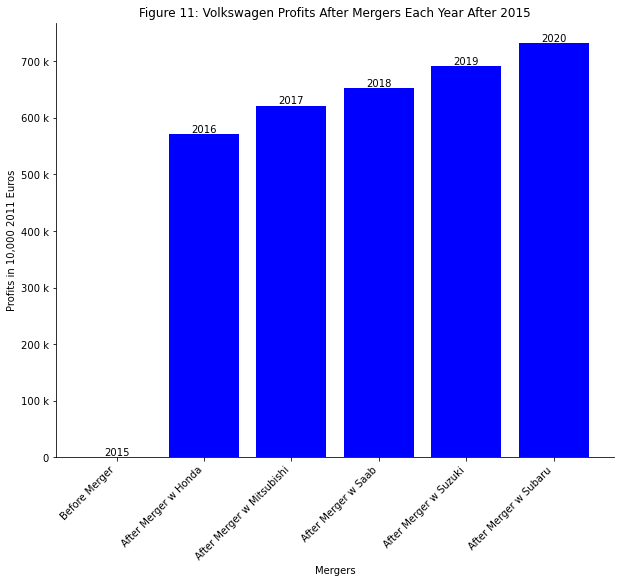

```python
fig, ax = plt.subplots(figsize=(10,8))
a = range(6)
a_labels = ['Before Merger','After Merger w Honda','After Merger w Mitsubishi','After Merger w Saab','After Merger w Suzuki','After Merger w Subaru']
y = [before_merger, honda_profits, mitsubishi_profits, saab_profits, suzuki_profits, subaru_profits]
plt.bar(a, y, color='blue', align='center')
plt.xticks(a, a_labels, rotation=45, ha='right')
ax.yaxis.set_major_formatter(FuncFormatter(y_fmt))
ax.set_ylabel('Profits in 10,000 2011 Euros')
ax.set_xlabel('Mergers')
ax.set_title('Figure 11: Volkswagen Profits After Mergers Each Year After 2015')
ax.spines['right'].set_visible(False)
ax.spines['top'].set_visible(False)

rects = ax.patches

labels = ['2015','2016','2017','2018','2019','2020']

for rect, label in zip(rects, labels):
    height = rect.get_height()
    ax.text(rect.get_x() + rect.get_width() / 2, height + 5, label,
            ha='center', va='bottom')
```